# Assignment 4, Task 1

### Part 2: PCA

```r
#Following along witht the lab, I will convert the filtered data into continuous numeric data with no NA values, and so that every numeric variables has a mean of 0 and a standard deviation of 1.

nutrients_filt_long <- nutrients_filtered %>%
  pivot_longer(names_to = 'name', values_to = 'values', where(is.numeric))
```

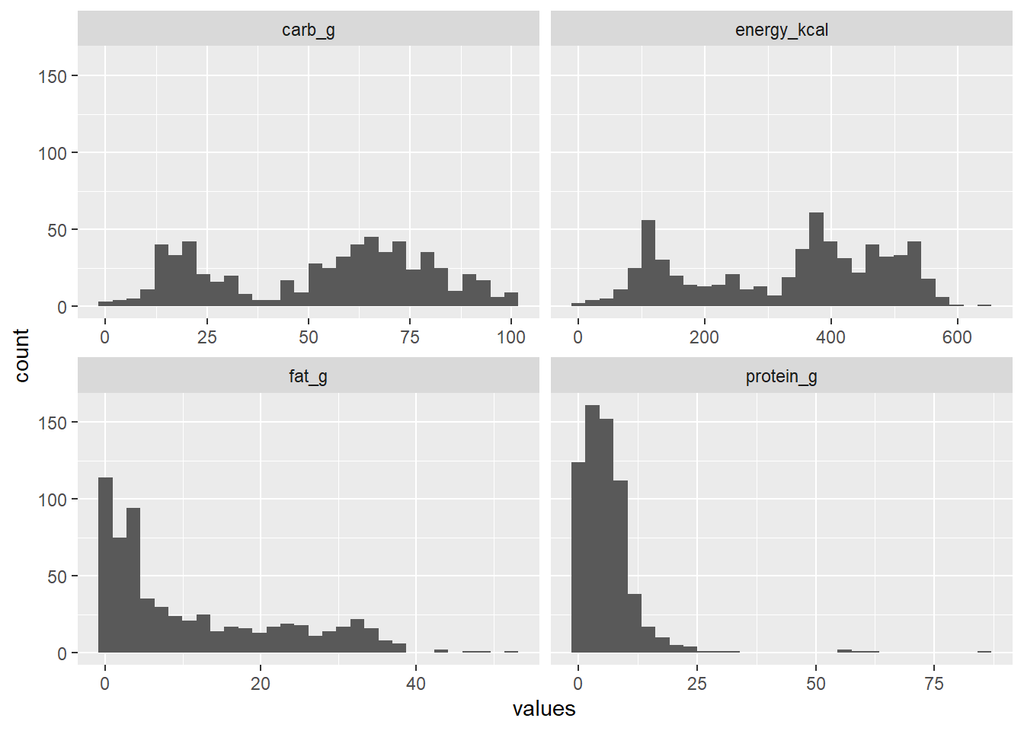

```r
ggplot(nutrients_filt_long, aes(x = values)) +
  geom_histogram() +
  facet_wrap(~name, scales = 'free_x')
```

```r
nutrient_pca <- nutrients_filtered %>%
  select(where(is.numeric)) %>%
  prcomp(scale = TRUE)

nutrient_pca
```

```
Standard deviations (1, .., p=4):
[1] 1.4467946 1.1098849 0.8127237 0.1200877

Rotation (n x k) = (4 x 4):
                  PC1         PC2          PC3        PC4
energy_kcal -0.684658  0.09555631 -0.004744418 -0.7225579
protein_g   -0.236891 -0.68726747  0.674438229  0.1291478
fat_g       -0.554466 -0.30584028 -0.600024361  0.4888762
carb_g      -0.409504  0.65191575  0.430210800  0.4714138
```

- `sdev` is the standard deviation (square root of explained variance captured by each principal component)
- `rotation` is the translation of base variables to principal components (and vice versa)
- `center` is the factor applied for centering of the variables
- `scale` is the factor for rescaling of the variables
- `x` is a dataframe of all observations transformed to their new values in PC1, 2, etc.

```r
nutrient_pca$rotation
```

```
                  PC1         PC2          PC3        PC4
energy_kcal -0.684658  0.09555631 -0.004744418 -0.7225579
protein_g   -0.236891 -0.68726747  0.674438229  0.1291478
fat_g       -0.554466 -0.30584028 -0.600024361  0.4888762
carb_g      -0.409504  0.65191575  0.430210800  0.4714138
```

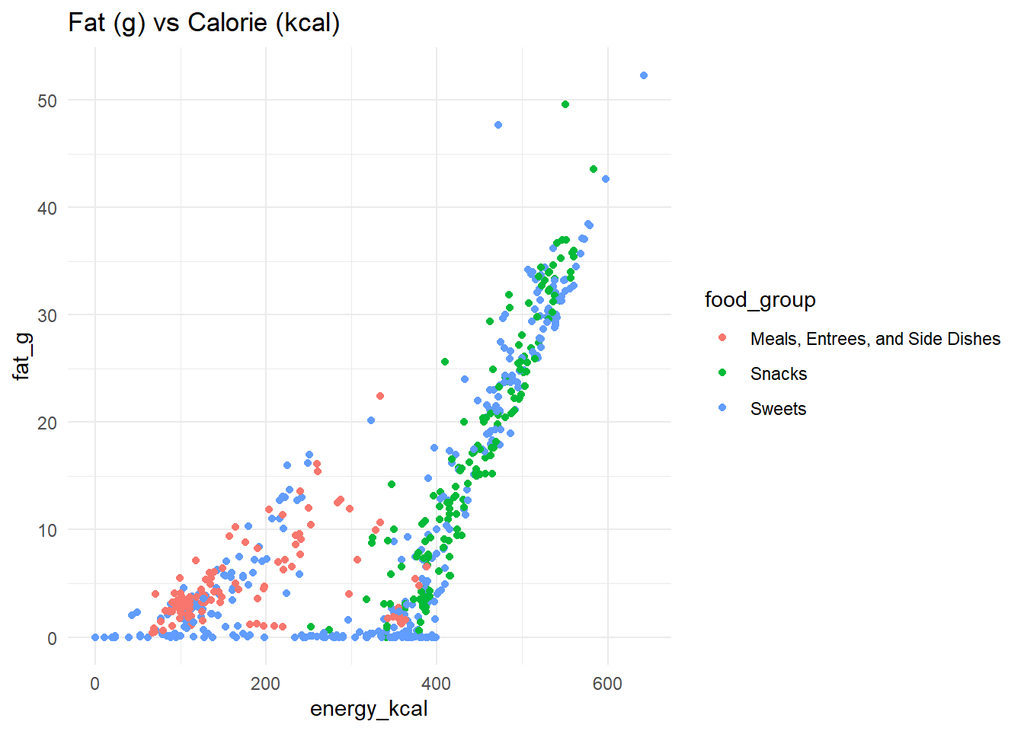

```r
fat_plot <- ggplot() +
  geom_point(data = nutrients_filtered, aes(x = energy_kcal, y = fat_g, color = food_group)) +
  theme_minimal() +
  labs(title = 'Fat (g) vs Calorie (kcal)')

pro_plot <- ggplot() +
  geom_point(data = nutrients_filtered, aes(x = energy_kcal, y = protein_g, color = food_group)) +
  theme_minimal() +
  labs(title = 'Protein (g) vs Calorie (kcal)')

carb_plot <- ggplot() +
  geom_point(data = nutrients_filtered, aes(x = energy_kcal, y = carb_g, color = food_group)) +
  theme_minimal() +
  labs(title = 'Carbs (g) vs Calorie (kcal)')

fat_plot
```

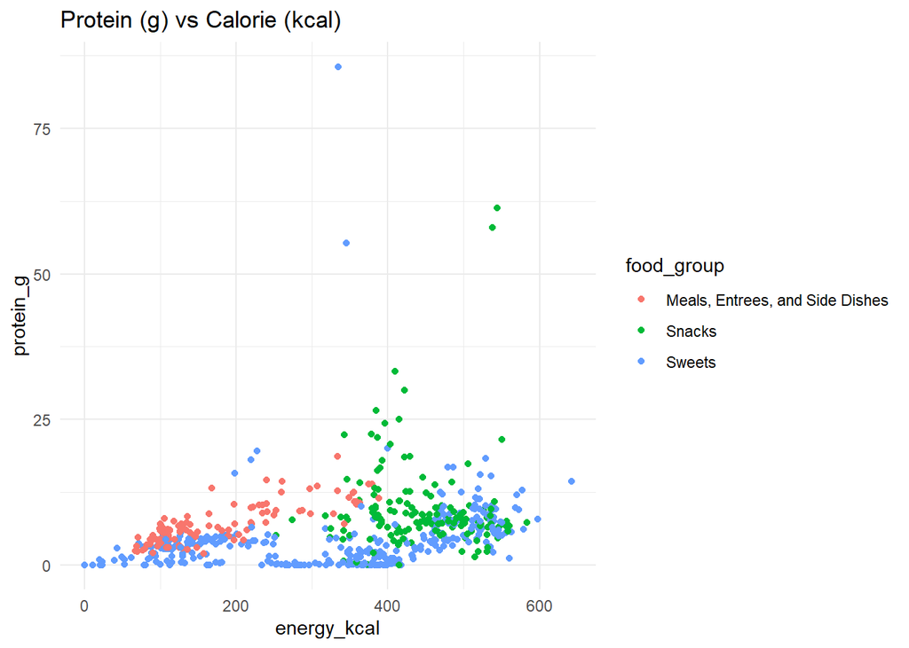

```r
pro_plot
```

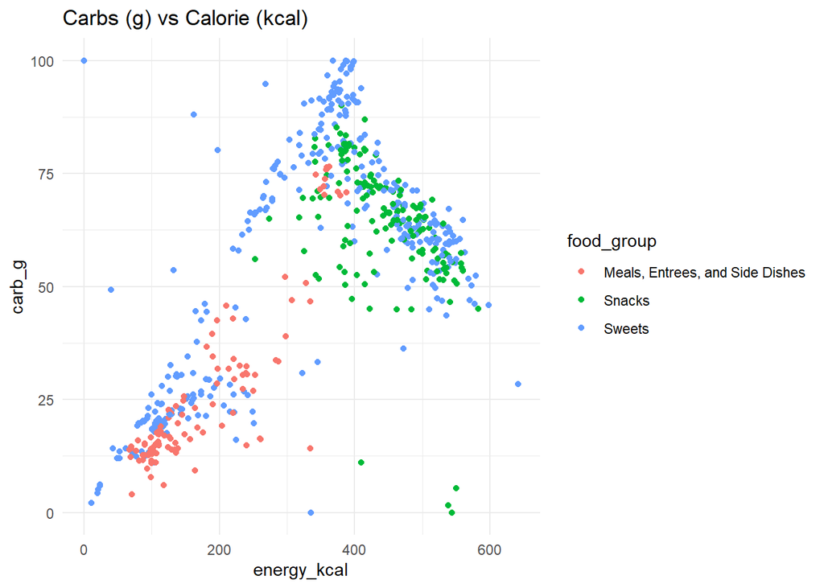

```r
carb_plot
```

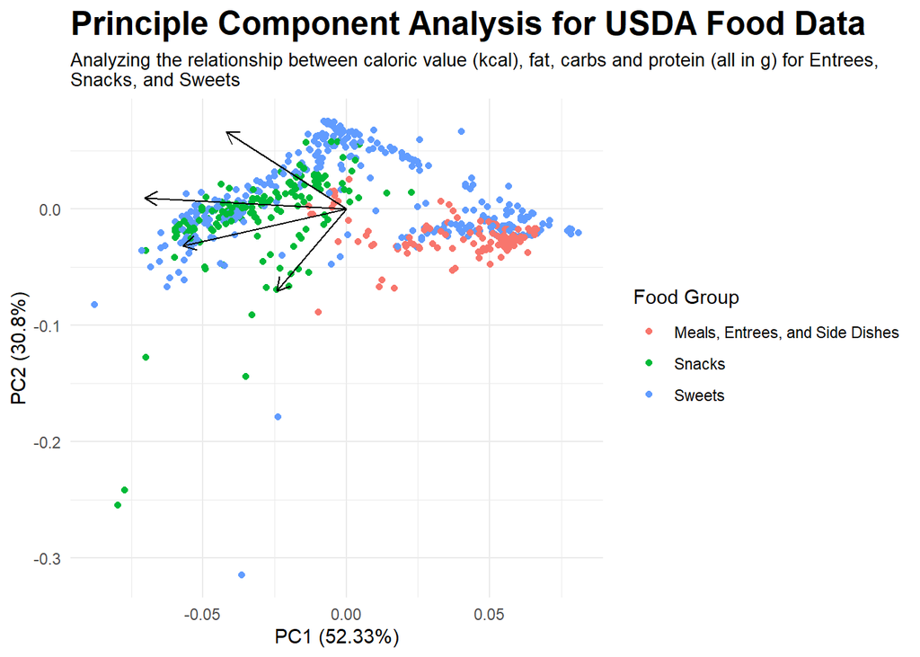

```r
nutrient_biplot <- autoplot(nutrient_pca,
         data = nutrients_filtered,
         loadings = TRUE,
         colour = 'food_group',
        loadings.colour = "black",
        loadings.label.colour = "black",
        loadings.label.vjust = -0.5
        ) +
  scale_color_discrete() +
  theme_minimal() +
  labs(title = 'Principle Component Analysis for USDA Food Data',
  subtitle = 'Analyzing the relationship between caloric value (kcal), fat, carbs and protein (all in g) for Entrees, \nSnacks, and Sweets',
  color = 'Food Group') +
  theme(plot.title = element_text(family = '', face = 'bold', size = 18),
        plot.subtitle = element_text(size = 10))

nutrient_biplot # + plot_annotation(
```

```r
#   title = 'Principle Component Analysis for USDA Food Data',
#   subtitle = 'Analyzing the relationship between caloric value (kcal), fat, carbs and protein (all in g) for Entrees, /nSnacks, and Sweets'
# )
```

## Data Citation

U.S. Department of Agriculture, Agricultural Research Service. FoodData Central, 2019. fdc.nal.usda.gov.